# t-test html

Jennifer Vance

2023-04-28

```r
library(ttest)


#generate x and y
#and set alpha
set.seed(32); x=rnorm(30,mean=10,sd=15)
set.seed(35); y=rnorm(30,mean=8,sd=15)
ans1=myttest(x,y,alpha=0.05,paired = FALSE)
print(ans1)
```

[[1]]

| x | y |
| --- | --- |
| 10.2196081 | 23.9768799 |
| 23.0993306 | 9.9932177 |
| -5.4191930 | 7.4893398 |
| 20.2849694 | 7.3253548 |
| 16.7415547 | 58.0675679 |
| 16.1052646 | 2.1062371 |
| 14.2709705 | 14.1584902 |
| 0.6353591 | -0.4327815 |
| 22.5948402 | 25.8683998 |
| 14.6691879 | 13.2360224 |
| 17.1288021 | 15.6733114 |
| 8.4986494 | 14.6801061 |
| 13.0526878 | -3.5257172 |
| 8.5884746 | 0.4833640 |
| 11.5035229 | -20.6288073 |
| 5.9765910 | -18.6800779 |
| 30.1908762 | 20.9637599 |
| 7.8034886 | 2.8139316 |
| 10.7464855 | 35.5739193 |
| 22.5059925 | 33.0962525 |
| 5.6366368 | 18.2636398 |
| -6.2710294 | 22.3543585 |
| 24.0899482 | 23.0283686 |
| 15.4120293 | 27.1435495 |
| 21.1048903 | 3.1904161 |
| 23.2285259 | 16.6768132 |
| 17.9298838 | 15.3065145 |
| -20.7546973 | 16.2927119 |
| 24.7325038 | 16.5134456 |
| 17.1020128 | 13.2435091 |

$CI [1] -7.623130 6.100201 attr(,“conf.level”) [1] 0.95

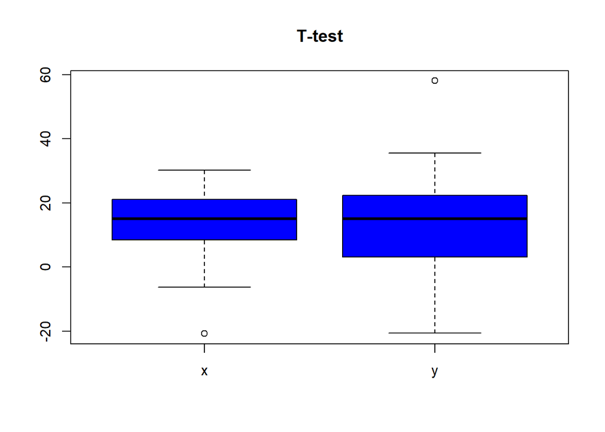

```r
plot(ans1)
```

$baseR $baseR$stats [,1] [,2] [1,] -6.271029 -20.628807 [2,] 8.498649 3.190416 [3,] 15.040609 14.993310 [4,] 21.104890 22.354358 [5,] 30.190876 35.573919

$baseR$n [1] 30 30

$baseR$conf [,1] [,2] [1,] 11.40412 9.465141 [2,] 18.67710 20.521479

$baseR$out [1] -20.75470 58.06757

$baseR$group [1] 1 2

$baseR$names [1] “x” “y”

$ggplot2

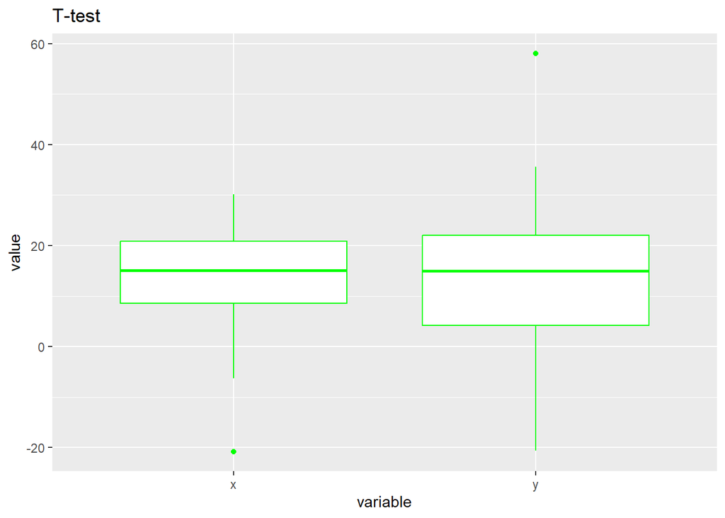

```r
set.seed(32); x=rnorm(30,mean=10,sd=5)
set.seed(35); y=rnorm(30,mean=8,sd=15)
ans2=myttest(x,y,alpha=0.05,paired = FALSE)
print(ans2)
```

[[1]]

| x | y |
| --- | --- |
| 10.0732027 | 23.9768799 |
| 14.3664435 | 9.9932177 |
| 4.8602690 | 7.4893398 |
| 13.4283231 | 7.3253548 |
| 12.2471849 | 58.0675679 |
| 12.0350882 | 2.1062371 |
| 11.4236568 | 14.1584902 |
| 6.8784530 | -0.4327815 |
| 14.1982801 | 25.8683998 |
| 11.5563960 | 13.2360224 |
| 12.3762674 | 15.6733114 |
| 9.4995498 | 14.6801061 |
| 11.0175626 | -3.5257172 |
| 9.5294915 | 0.4833640 |
| 10.5011743 | -20.6288073 |
| 8.6588637 | -18.6800779 |
| 16.7302921 | 20.9637599 |
| 9.2678295 | 2.8139316 |
| 10.2488285 | 35.5739193 |
| 14.1686642 | 33.0962525 |
| 8.5455456 | 18.2636398 |
| 4.5763235 | 22.3543585 |
| 14.6966494 | 23.0283686 |
| 11.8040098 | 27.1435495 |
| 13.7016301 | 3.1904161 |
| 14.4095086 | 16.6768132 |
| 12.6432946 | 15.3065145 |
| -0.2515658 | 16.2927119 |
| 14.9108346 | 16.5134456 |
| 12.3673376 | 13.2435091 |

$CI [1] -8.672098 3.086584 attr(,“conf.level”) [1] 0.95

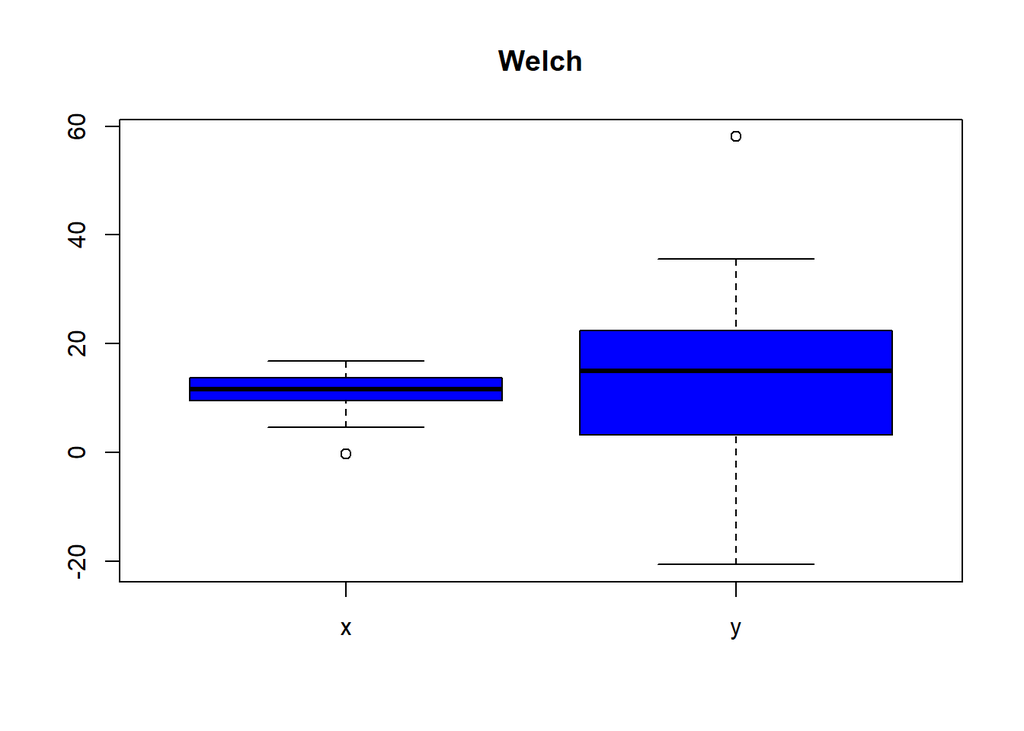

```r
plot(ans2)
```

$baseR $baseR$stats [,1] [,2] [1,] 4.576324 -20.628807 [2,] 9.499550 3.190416 [3,] 11.680203 14.993310 [4,] 13.701630 22.354358 [5,] 16.730292 35.573919

$baseR$n [1] 30 30

$baseR$conf [,1] [,2] [1,] 10.46804 9.465141 [2,] 12.89237 20.521479

$baseR$out [1] -0.2515658 58.0675679

$baseR$group [1] 1 2

$baseR$names [1] “x” “y”

$ggplot2

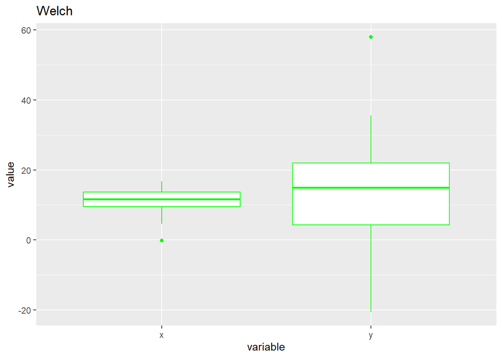

```r
set.seed(32); x=rnorm(30,mean=10,sd=15)
set.seed(35); y = x+ rnorm(30, 5 ,4)
ans3=myttest(x,y,alpha=0.05,paired = TRUE)
print(ans3)
```

[[1]]

| x | y |
| --- | --- |
| 10.2196081 | 19.4801094 |
| 23.0993306 | 28.6308554 |
| -5.4191930 | -0.5553691 |
| 20.2849694 | 25.1050640 |
| 16.7415547 | 35.0929062 |
| 16.1052646 | 19.5335945 |
| 14.2709705 | 20.9132346 |
| 0.6353591 | 3.3866174 |
| 22.5948402 | 32.3597468 |
| 14.6691879 | 21.0654605 |
| 17.1288021 | 24.1750185 |
| 8.4986494 | 15.2800110 |
| 13.0526878 | 14.9791632 |
| 8.5884746 | 11.5840384 |
| 11.5035229 | 8.8691743 |
| 5.9765910 | 3.8619035 |
| 30.1908762 | 38.6478788 |
| 7.8034886 | 11.4205370 |
| 10.7464855 | 23.0995306 |
| 22.5059925 | 34.1983265 |
| 5.6366368 | 13.3736074 |
| -6.2710294 | 2.5567995 |
| 24.0899482 | 33.0975132 |
| 15.4120293 | 25.5169758 |
| 21.1048903 | 24.8223346 |
| 23.2285259 | 30.5423427 |
| 17.9298838 | 24.8782877 |
| -20.7546973 | -13.5433074 |
| 24.7325038 | 32.0027560 |
| 17.1020128 | 23.5002819 |

$CI [1] -8.082480 -5.015335 attr(,“conf.level”) [1] 0.95

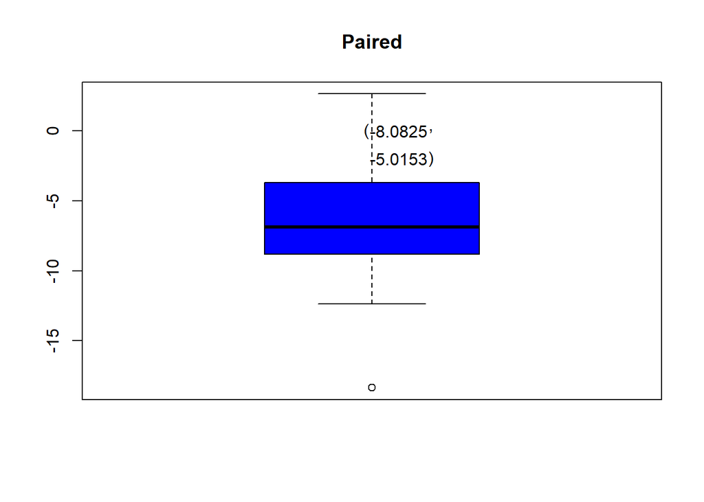

```r
plot(ans3)
```

$baseR $baseR$stats [,1] [1,] -12.353045 [2,] -8.827829 [3,] -6.864883 [4,] -3.717444 [5,] 2.634349

$baseR$n [1] 30

$baseR$conf [,1] [1,] -8.339061 [2,] -5.390704

$baseR$out [1] -18.35135

$baseR$group [1] 1

$baseR$names [1] “”

$ggplot2

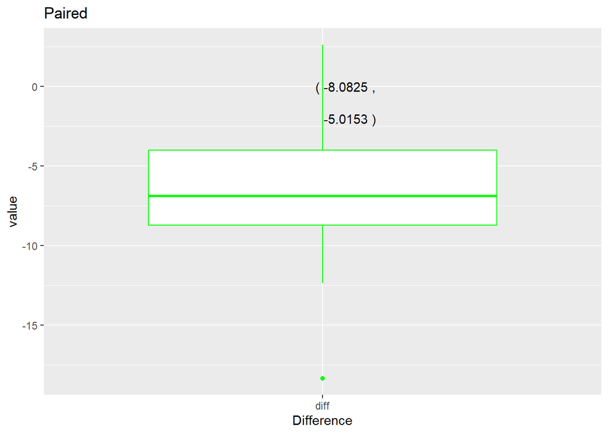